# Лабораторная работа №7

Имитационное моделирование

Ибрахим Мохсейн Алькамаль

1032225432@rudn.ru

Российский университет дружбы народов

2026-09-04

# Информация

## Докладчик

- Ибрахим Мохсейн Алькамаль
- Российский университет дружбы народов

# Цель работы

- Изучить принципы дискретно-событийного моделирования.
- Рассмотреть системы массового обслуживания.
- Реализовать и исследовать модели `M/M/c` и Росса.
- Рассчитать основные характеристики систем.
- Сравнить результаты симуляции с аналитическими значениями.

# Выполнение лабораторной работы

## Подготовка рабочего проекта

- Создан проект `lab07/project`.
- Использован скрипт `setup_project.jl`.
- Сформировано проектное окружение Julia.
- Установлена зависимость `DrWatson`.

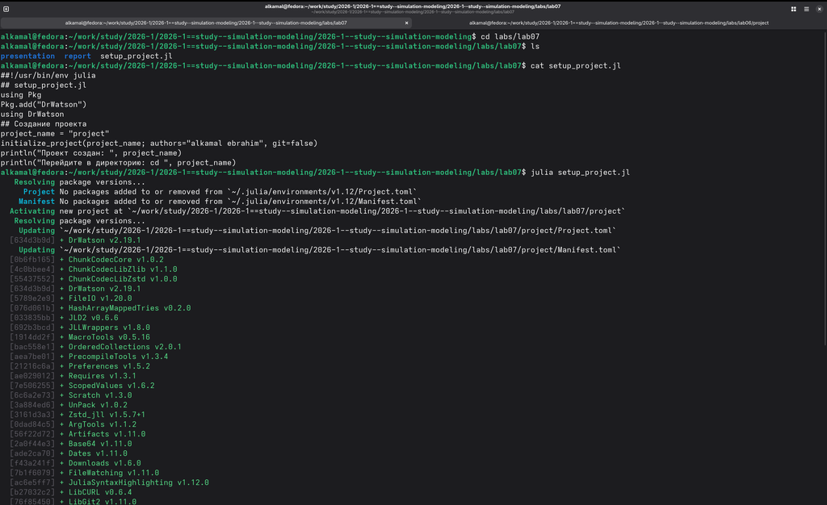

Рисунок 1: Создание рабочего проекта lab07 и инициализация окружения Julia

## Проверка проектного окружения

- Проект запущен командой `julia --project=.`.
- Состав окружения проверен с помощью `Pkg.status()`.
- Проверено наличие необходимых пакетов: `ConcurrentSim`, `Distributions`, `ResumableFunctions`, `StableRNGs`, `DataFrames` и `Plots`.

[figure not shown]

Рисунок 2: Проверка установленных пакетов проектного окружения Julia

## Выполнение модели M/M/c

- Запущен скрипт `run_mmc.jl`.
- Исследована модель `M/M/2`.
- Параметры: $\lambda=0.9$, $\mu=0.5$, $c=2$.
- Рассчитаны аналитические характеристики системы.
- График сохранён в `plots/mmc/mmc_analytics.png`.

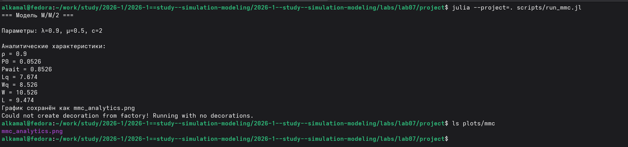

Рисунок 3: Выполнение модели M/M/2 и расчёт аналитических характеристик

## Преобразование модели M/M/c в литературный стиль

- Подготовлен файл `run_mmc_literary.jl`.
- Выполнена обработка с помощью `tangle.jl`.
- Сформирован чистый Julia-скрипт.
- Созданы документ Quarto и Jupyter Notebook.

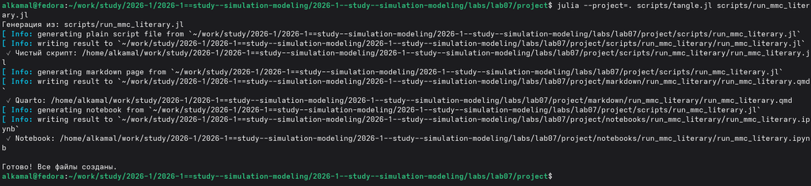

Рисунок 4: Генерация Julia-скрипта, документа Quarto и Jupyter Notebook для модели M/M/c

## Выполнение модели M/M/c в Jupyter Notebook

- Открыт `run_mmc_literary.ipynb`.
- Выполнена литературная версия модели.
- Представлены функции расчёта аналитических характеристик.
- Реализовано построение соответствующих графиков.

[figure not shown]

Рисунок 5: Выполнение литературной версии модели M/M/c в Jupyter Notebook

## Выполнение модели Росса

- Запущен скрипт `run_ross.jl`.
- Параметры: `N = 10`, `S = 3`, `R = 2`.
- Интенсивности: $\lambda = 1/100$, $\mu = 1/1.0$.
- Система определена как стационарная.
- Время до падения в одиночном прогоне — `78.36` часов.
- Запущены массовые прогоны для различных конфигураций.

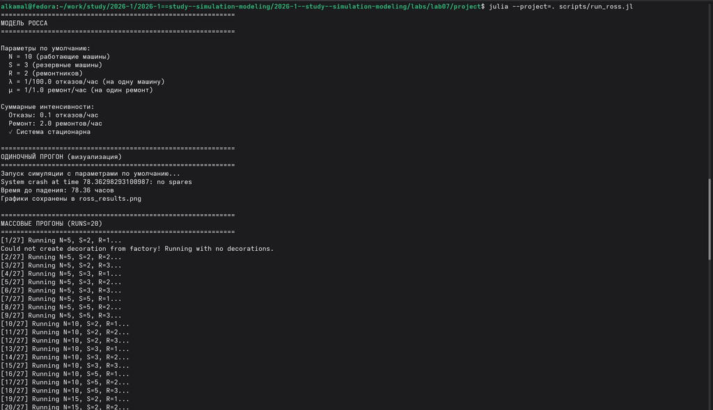

Рисунок 6: Выполнение одиночного и массовых прогонов модели Росса

## Анализ результатов моделирования Росса

- Выполнена визуализация результатов массовых прогонов.
- Результаты симуляции сравнены с аналитическими значениями.
- Построены тепловые карты для `R = 1` и `R = 2`.
- Проведён анализ загрузки ремонтников.
- Графики сохранены в каталоге `plots/ross`.

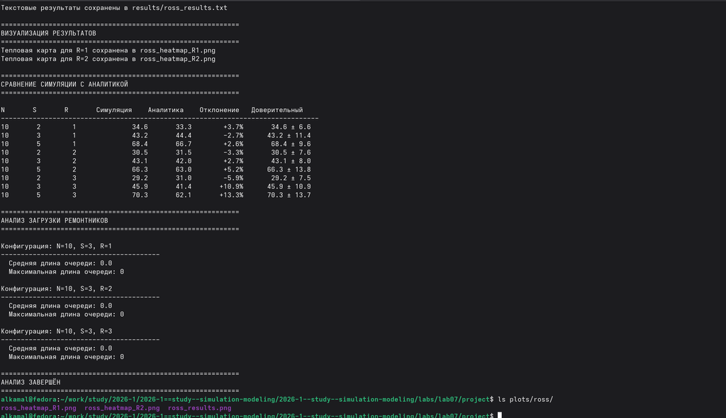

Рисунок 7: Сравнение результатов симуляции и аналитических значений модели Росса

## Преобразование модели Росса в литературный стиль

- Подготовлен файл `run_ross_literary.jl`.
- Выполнена обработка с помощью `tangle.jl`.
- Сформирован чистый Julia-скрипт.
- Созданы документ Quarto и Jupyter Notebook.

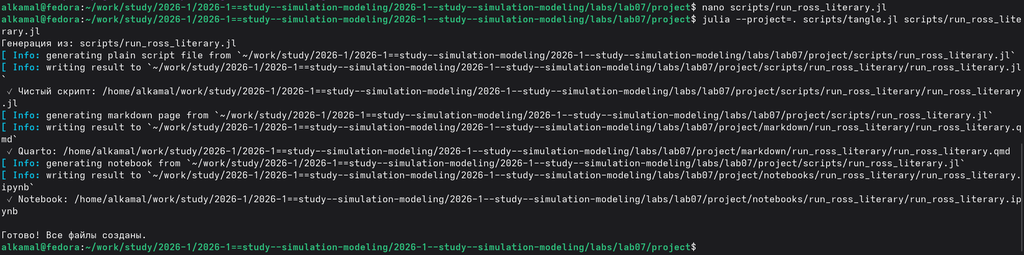

Рисунок 8: Генерация Julia-скрипта, документа Quarto и Jupyter Notebook для модели Росса

## Выполнение модели Росса в Jupyter Notebook

- Выполнен `run_ross_literary.ipynb`.
- Представлены функции анализа загрузки ремонтников.
- Представлена основная функция запуска модели.
- Выполняется работа с заданными параметрами.
- Реализована проверка стационарности системы.

[figure not shown]

Рисунок 9: Выполнение литературной версии модели Росса в Jupyter Notebook

# Выводы

- Реализованы и исследованы дискретно-событийные модели `M/M/c` и Росса.
- Для `M/M/c` рассчитаны аналитические характеристики и построены графики.
- Для модели Росса выполнены одиночный и массовые прогоны.
- Проведено сравнение симуляции с аналитическими значениями.
- Исследована загрузка ремонтников.
- Результаты представлены графиками и тепловыми картами.
- Для обеих моделей подготовлены литературные версии в форматах Quarto и Jupyter Notebook.